# Tema 2.2. Manipulación de datos

#### 2.1.6.1 📝 Ejercicio: select()

—————————————————————————————————

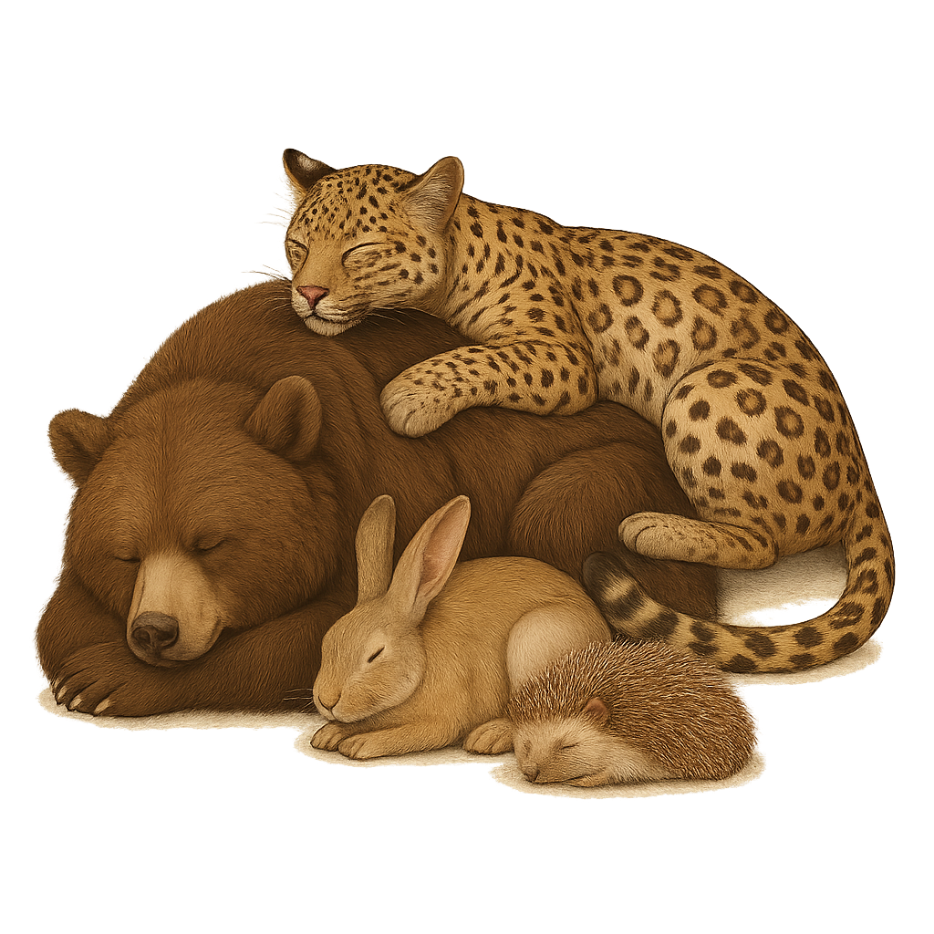

- Con el data set de msleep, crea un nuevo data.frame que contenga las variables relacionadas con el sueño.
- Con el data set de msleep, crea un nuevo data.frame que contenga todas las variables excepto el estado de conservacion.
- (extra) Crea un nuevo objeto (data frame) con el orden, género y nombre al principio y que incluya todas las demás columnas excepto el tiempo despierto.

# 3 Ejercicio completo con mtcars

- `select()` para **elegir columnas (variables)**
- `slice()` para **seleccionar filas según su posición (observaciones)**
- `filter()` para **seleccionar filas según valores (observaciones)**

Primero veremos cómo se hacen en **base R** y luego con el **tidyverse**. Usaremos el dataset incorporado en R llamado `mtcars`, que contiene información de automóviles.

Podéis ver más información para la exploración de esta base de datos aquí:

https://cran.r-project.org/web/packages/explore/vignettes/explore-mtcars.html

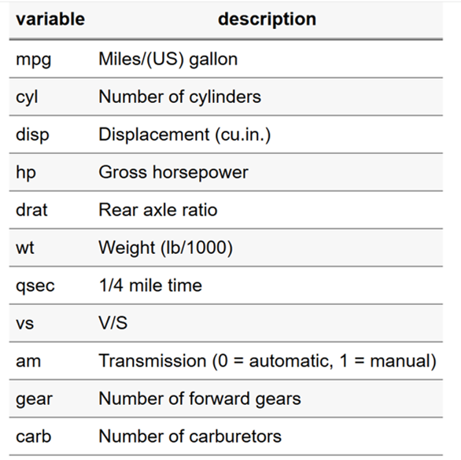

```r
# Cargar librerías
library(tidyverse) #para dplyr y ggplot

# Vistazo rápido a los datos
head(mtcars, 5)
```

```
                   mpg cyl disp  hp drat    wt  qsec vs am gear carb
Mazda RX4         21.0   6  160 110 3.90 2.620 16.46  0  1    4    4
Mazda RX4 Wag     21.0   6  160 110 3.90 2.875 17.02  0  1    4    4
Datsun 710        22.8   4  108  93 3.85 2.320 18.61  1  1    4    1
Hornet 4 Drive    21.4   6  258 110 3.08 3.215 19.44  1  0    3    1
Hornet Sportabout 18.7   8  360 175 3.15 3.440 17.02  0  0    3    2
```

```r
names(mtcars)
```

```
 [1] "mpg"  "cyl"  "disp" "hp"   "drat" "wt"   "qsec" "vs"   "am"   "gear"
[11] "carb"
```

```r
head(mtcars, n = 4) #rbase
```

```
                mpg cyl disp  hp drat    wt  qsec vs am gear carb
Mazda RX4      21.0   6  160 110 3.90 2.620 16.46  0  1    4    4
Mazda RX4 Wag  21.0   6  160 110 3.90 2.875 17.02  0  1    4    4
Datsun 710     22.8   4  108  93 3.85 2.320 18.61  1  1    4    1
Hornet 4 Drive 21.4   6  258 110 3.08 3.215 19.44  1  0    3    1
```

```r
mtcars |> #dplyr #pipa
  head(n = 4)
```

```
                mpg cyl disp  hp drat    wt  qsec vs am gear carb
Mazda RX4      21.0   6  160 110 3.90 2.620 16.46  0  1    4    4
Mazda RX4 Wag  21.0   6  160 110 3.90 2.875 17.02  0  1    4    4
Datsun 710     22.8   4  108  93 3.85 2.320 18.61  1  1    4    1
Hornet 4 Drive 21.4   6  258 110 3.08 3.215 19.44  1  0    3    1
```

**Nuestro objetivo:** seleccionar la mejor marca (no real), que tiene un mayor número de millas por US gallon multiplicado por el número de cilindos. Para lo que:

## 3.1 Conoce tus datos para una pregunta concreta

```r
#### readr (read rectangular data) ####
write.table(mtcars, "resultados\\cars.txt", sep = "\t")

cars_df <- read.table("resultados\\cars.txt", sep = "\t",
                      header = TRUE)

#check the data
str(cars_df)
```

```
'data.frame':   32 obs. of  11 variables:
 $ mpg : num  21 21 22.8 21.4 18.7 18.1 14.3 24.4 22.8 19.2 ...
 $ cyl : int  6 6 4 6 8 6 8 4 4 6 ...
 $ disp: num  160 160 108 258 360 ...
 $ hp  : int  110 110 93 110 175 105 245 62 95 123 ...
 $ drat: num  3.9 3.9 3.85 3.08 3.15 2.76 3.21 3.69 3.92 3.92 ...
 $ wt  : num  2.62 2.88 2.32 3.21 3.44 ...
 $ qsec: num  16.5 17 18.6 19.4 17 ...
 $ vs  : int  0 0 1 1 0 1 0 1 1 1 ...
 $ am  : int  1 1 1 0 0 0 0 0 0 0 ...
 $ gear: int  4 4 4 3 3 3 3 4 4 4 ...
 $ carb: int  4 4 1 1 2 1 4 2 2 4 ...
```

```r
glimpse(cars_df)
```

```
Rows: 32
Columns: 11
$ mpg  <dbl> 21.0, 21.0, 22.8, 21.4, 18.7, 18.1, 14.3, 24.4, 22.8, 19.2, 17.8,…
$ cyl  <int> 6, 6, 4, 6, 8, 6, 8, 4, 4, 6, 6, 8, 8, 8, 8, 8, 8, 4, 4, 4, 4, 8,…
$ disp <dbl> 160.0, 160.0, 108.0, 258.0, 360.0, 225.0, 360.0, 146.7, 140.8, 16…
$ hp   <int> 110, 110, 93, 110, 175, 105, 245, 62, 95, 123, 123, 180, 180, 180…
$ drat <dbl> 3.90, 3.90, 3.85, 3.08, 3.15, 2.76, 3.21, 3.69, 3.92, 3.92, 3.92,…
$ wt   <dbl> 2.620, 2.875, 2.320, 3.215, 3.440, 3.460, 3.570, 3.190, 3.150, 3.…
$ qsec <dbl> 16.46, 17.02, 18.61, 19.44, 17.02, 20.22, 15.84, 20.00, 22.90, 18…
$ vs   <int> 0, 0, 1, 1, 0, 1, 0, 1, 1, 1, 1, 0, 0, 0, 0, 0, 0, 1, 1, 1, 1, 0,…
$ am   <int> 1, 1, 1, 0, 0, 0, 0, 0, 0, 0, 0, 0, 0, 0, 0, 0, 0, 1, 1, 1, 0, 0,…
$ gear <int> 4, 4, 4, 3, 3, 3, 3, 4, 4, 4, 4, 3, 3, 3, 3, 3, 3, 4, 4, 4, 3, 3,…
$ carb <int> 4, 4, 1, 1, 2, 1, 4, 2, 2, 4, 4, 3, 3, 3, 4, 4, 4, 1, 2, 1, 1, 2,…
```

```r
head(cars_df)
```

```
                   mpg cyl disp  hp drat    wt  qsec vs am gear carb
Mazda RX4         21.0   6  160 110 3.90 2.620 16.46  0  1    4    4
Mazda RX4 Wag     21.0   6  160 110 3.90 2.875 17.02  0  1    4    4
Datsun 710        22.8   4  108  93 3.85 2.320 18.61  1  1    4    1
Hornet 4 Drive    21.4   6  258 110 3.08 3.215 19.44  1  0    3    1
Hornet Sportabout 18.7   8  360 175 3.15 3.440 17.02  0  0    3    2
Valiant           18.1   6  225 105 2.76 3.460 20.22  1  0    3    1
```

```r
tail(cars_df)
```

```
                mpg cyl  disp  hp drat    wt qsec vs am gear carb
Porsche 914-2  26.0   4 120.3  91 4.43 2.140 16.7  0  1    5    2
Lotus Europa   30.4   4  95.1 113 3.77 1.513 16.9  1  1    5    2
Ford Pantera L 15.8   8 351.0 264 4.22 3.170 14.5  0  1    5    4
Ferrari Dino   19.7   6 145.0 175 3.62 2.770 15.5  0  1    5    6
Maserati Bora  15.0   8 301.0 335 3.54 3.570 14.6  0  1    5    8
Volvo 142E     21.4   4 121.0 109 4.11 2.780 18.6  1  1    4    2
```

```r
summary(cars_df)
```

```
      mpg             cyl             disp             hp
 Min.   :10.40   Min.   :4.000   Min.   : 71.1   Min.   : 52.0
 1st Qu.:15.43   1st Qu.:4.000   1st Qu.:120.8   1st Qu.: 96.5
 Median :19.20   Median :6.000   Median :196.3   Median :123.0
 Mean   :20.09   Mean   :6.188   Mean   :230.7   Mean   :146.7
 3rd Qu.:22.80   3rd Qu.:8.000   3rd Qu.:326.0   3rd Qu.:180.0
 Max.   :33.90   Max.   :8.000   Max.   :472.0   Max.   :335.0
      drat             wt             qsec             vs
 Min.   :2.760   Min.   :1.513   Min.   :14.50   Min.   :0.0000
 1st Qu.:3.080   1st Qu.:2.581   1st Qu.:16.89   1st Qu.:0.0000
 Median :3.695   Median :3.325   Median :17.71   Median :0.0000
 Mean   :3.597   Mean   :3.217   Mean   :17.85   Mean   :0.4375
 3rd Qu.:3.920   3rd Qu.:3.610   3rd Qu.:18.90   3rd Qu.:1.0000
 Max.   :4.930   Max.   :5.424   Max.   :22.90   Max.   :1.0000
       am              gear            carb
 Min.   :0.0000   Min.   :3.000   Min.   :1.000
 1st Qu.:0.0000   1st Qu.:3.000   1st Qu.:2.000
 Median :0.0000   Median :4.000   Median :2.000
 Mean   :0.4062   Mean   :3.688   Mean   :2.812
 3rd Qu.:1.0000   3rd Qu.:4.000   3rd Qu.:4.000
 Max.   :1.0000   Max.   :5.000   Max.   :8.000
```

```r
names(cars_df)
```

```
 [1] "mpg"  "cyl"  "disp" "hp"   "drat" "wt"   "qsec" "vs"   "am"   "gear"
[11] "carb"
```

```r
dim(cars_df)
```

```
[1] 32 11
```

```r
nrow(cars_df)
```

```
[1] 32
```

```r
ncol(cars_df)
```

```
[1] 11
```

———————————————————————————————————

#### 3.1.0.1 📝 Ejercicio: conoce la estructura de tus datos

Piensa y escribe en una línea qué hace cada función y discutelo con el compañero

———————————————————————————————————

Recuerda, SIEMPRE debes conocer tus datos y dar esa información ANTES de empezar un análisis:

- ¿Qué tipo de datos tienes?
- ¿Cuántas observaciones? ¿Qué es tu unidad de observación?
- ¿Cuantas columnas? ¿Qué unidades y qué rangos tienen?

## 3.2 Selección de variables de interés: Rbase vs. tidyverse

Queremos seleccionar las variables `mpg` (millas por galón) y `cyl` (número de cilindros), además de la marca.

### 3.2.1 Con Base R

```r
select_mtcars_Rbase1 <- mtcars[, c("mpg", "cyl")]
select_mtcars_Rbase3 <- mtcars[, c(1, 2)]
```

### 3.2.2 Con tidyverse (`select()`)

```r
select_mtcars_tidyverse <- mtcars |>
  select(mpg, cyl)
```

#### 3.2.2.1 📝 Ejercicio: diferencias entre Rbase y tidyverse

¿Qué es más sencillo de entender? ¿y más reproducible de las tres opciones que hemos visto?

## 3.3 Filtramos los coches con un numero de cilindos mayor de 4

Queremos quedarnos solo con los coches que tienen más de **4 cilindros**.

### 3.3.1 Con Base R

```r
select_mtcars_filtado <- mtcars[select_mtcars_tidyverse$cyl > 4, ]
```

### 3.3.2 Con tidyverse (`filter()`)

```r
select_mtcars_tidyverse |>
  filter(cyl > 4)
```

```
                     mpg cyl
Mazda RX4           21.0   6
Mazda RX4 Wag       21.0   6
Hornet 4 Drive      21.4   6
Hornet Sportabout   18.7   8
Valiant             18.1   6
Duster 360          14.3   8
Merc 280            19.2   6
Merc 280C           17.8   6
Merc 450SE          16.4   8
Merc 450SL          17.3   8
Merc 450SLC         15.2   8
Cadillac Fleetwood  10.4   8
Lincoln Continental 10.4   8
Chrysler Imperial   14.7   8
Dodge Challenger    15.5   8
AMC Javelin         15.2   8
Camaro Z28          13.3   8
Pontiac Firebird    19.2   8
Ford Pantera L      15.8   8
Ferrari Dino        19.7   6
Maserati Bora       15.0   8
```

### 3.4.1 Con tidyverse (piping)

```r
cars_cyl <- cars_df |>
  select(cyl, mpg) |>
  filter(cyl > 4) |>
  mutate(mpg_cyl = mpg * cyl)|>
  arrange(mpg_cyl)
```

👉 Ventajas: más intuitivo, cada paso es claro y en “lenguaje natural”. 👉 Inconvenientes: requiere instalar/cargar dplyr.

### 3.4.2 Con Rbase (piping)

```r
#sin pipa
mtcars_Rbase1 <- mtcars[select_mtcars_tidyverse$cyl > 4, c("mpg", "cyl")]
mtcars_Rbase1$mpg_cyl <- mtcars_Rbase1$cyl * mtcars_Rbase1$mpg
mtcars_sorted <- mtcars_Rbase1[order(mtcars_Rbase1$mpg_cyl), ]

#con pipa:
mtcars_sorted <- mtcars |>
  (\(x) x[x$cyl > 4, c("mpg", "cyl")])() |>          # filtrar y seleccionar
  (\(x) transform(x, mpg_cyl = cyl * mpg))() |>      # crear nueva columna
  (\(x) x[order(x$mpg_cyl), ])()                     # ordenar
```

👉 Ventajas: usa solo R base, no necesita librerías adicionales. 👉 Inconvenientes: la sintaxis es más dificil para alumnos principiantes, menos legible.

## 3.5 Mostramos los resultados: nuestro primer gráfico

Gráfico base R

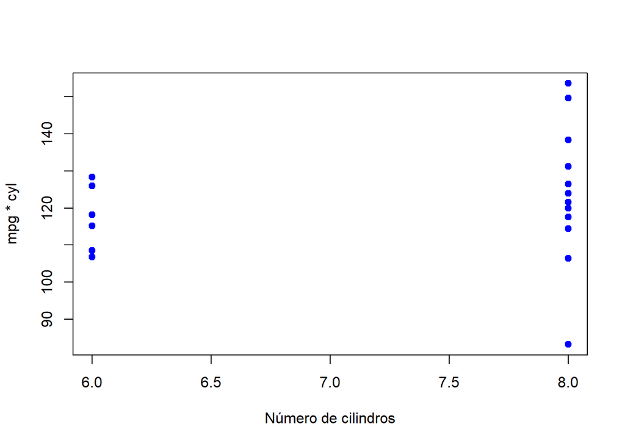

```r
plot(mtcars_sorted$cyl, mtcars_sorted$mpg_cyl,
     main = "",
     xlab = "Número de cilindros",
     ylab = "mpg * cyl",
     pch = 19, col = "blue")
```

Gráfico con ggplot2, paquete de gráficos de tidyverse

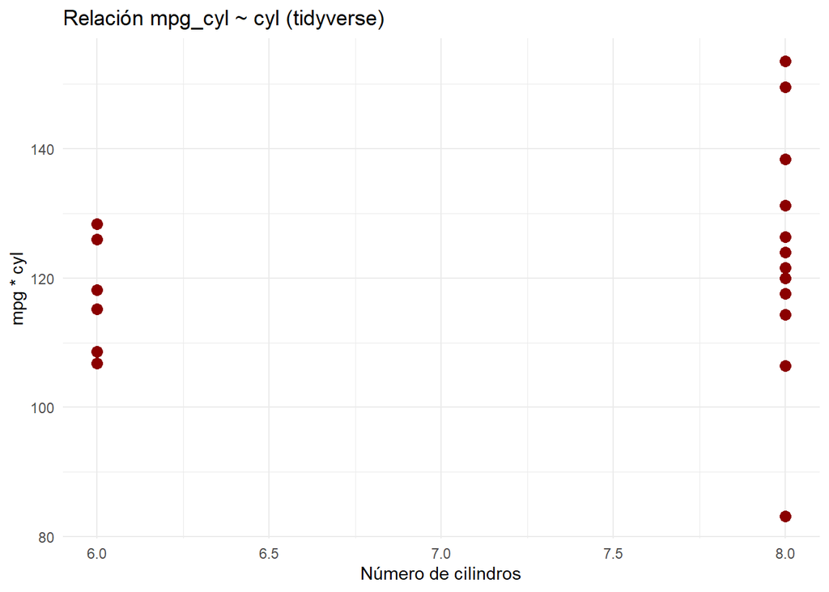

```r
ggplot(mtcars_sorted, aes(x = cyl, y = mpg_cyl)) +
  geom_point(color = "darkred", size = 3) +
  labs(title = "Relación mpg_cyl ~ cyl (tidyverse)",
       x = "Número de cilindros",
       y = "mpg * cyl") +
  theme_minimal()
```

#### 3.5.0.1 📝 Ejercicio: practica la selección y filtrado con la pipa

Ahora es vuestro turno 💡:

1. **Ejercicio 1:** Selecciona solo las columnas `mpg` y `hp` de `mtcars` usando tanto base R como tidyverse.
2. **Ejercicio 2:** Filtra los coches que tengan más de 100 caballos de potencia (`hp > 100`). Calcula la media de las cilindradas
3. **Ejercicio 3 (reto):** Usando tidyverse, selecciona las columnas `mpg`, `cyl` y `hp`, y quédate solo con los coches que tengan más de 20 mpg **y** 4 cilindros. Calcula la media, y rangos (mínimo, máximo) de mpg.

#### 3.5.0.2 **📤 Ejercicio: Envia las contestaciones de los ejercicios (2) y (3) por el aula virtual.**

# 4 Manipulación de datos: calculo de estadísticas

Podemos calcular estadísticas básicas sobre mtcars, tal y como ya hicimos en la sección anterior lo más fácil sería con `summary()`. Sin embargo, existen múltiples funciones que nos permiten usar y calcular estarísticas básicas de las distintas variables, como la media, la mínima, máxima, desviación estándar, o percentiles.

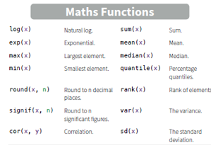

Rbase cheatsheet

Por favor, cuando calcules estatadísticas básicas sigue el protocolo para la exploración de datos que te facilito en al aula virtual, siguiendo [Zuur et al. (2009)](https://besjournals.onlinelibrary.wiley.com/doi/epdf/10.1111/j.2041-210X.2009.00001.x) y los siguientes principios:

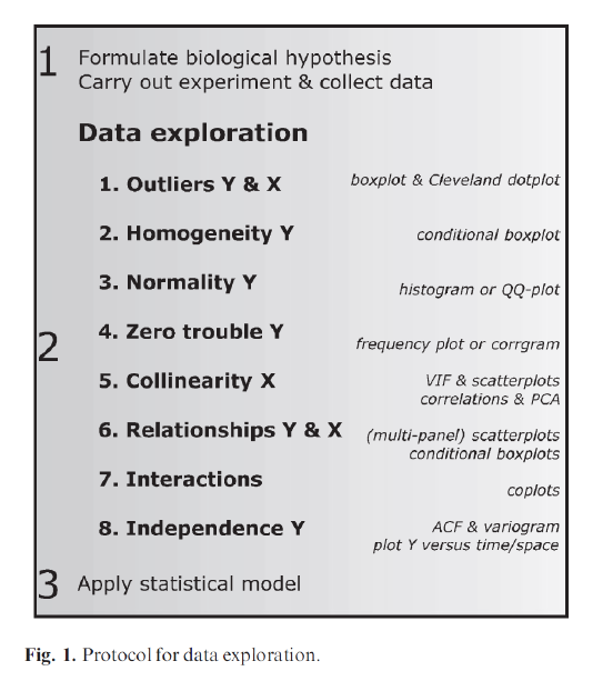

[Zuur et al. (2009) Methods in Ecology and Evolution](https://besjournals.onlinelibrary.wiley.com/doi/epdf/10.1111/j.2041-210X.2009.00001.x)

- **(0)** **Estructura de datos**: ¿qué unidad muestral tengo? ¿cuantas filas?; ¿Qué variables tengo?¿cuántas columnas y con qué unidades?; ¿Qué tipo de datos son cada columna?
- **(1) Datos ánomalos, ceros y celdas vacias**: ¿son reales? ¿Qué significado tienen en mis datos? ¿cómo debo tratarlos?
- **(2) Distribución de las variables**: ¿Proporciono medidas de centralidad y desviación de mis variables? ¿Son los datos normales? ¿Son homogéneos? ¿Debo eliminar, transformar o ignorar la distribución de las variables? ¿qué consecuencias tiene los cambios realizados?
- **(3) Relaciones e interacciones**: ¿Son importantes las relaciones entre variables para el análisis que quiero hacer?
- **(4) Colinealidad o correlaciones**: ¿Tengo colinealidad en mis datos?
- **(5) Independencia**: ¿son mis datos independientes entre si?

#### 4.0.0.1 📝 Ejercicio: calcular estadisticas básicas. Repasa cada uno de los puntos propuestos en Zuur et al. (2009) o los cinco puntos propuestos más arriba.

### 4.0.1 🚀 Selecciona ejemplos de TidyTuesday y explica los pasos que generalmente se realizan en la limpieza de datos.

https://rfordatascience.github.io/tidytuesday/about.html

# 5 Conclusión

- `select()` = elegir columnas (variables).
- `filter()` = elegir filas (observaciones).
- La forma tidyverse es más legible cuando se encadenan varias operaciones, especialmente cuando se tuliza con la pipa.

[figure not shown]